# Poverty and Child Mortality in 2020

Workshop 2: Automated Data Analysis & Reporting, Generative AI for Work & Research (The GRAPH Courses)

Ryan Arias Delafosse

October 2026

## Data

This report uses two indicators from [Gapminder](https://www.gapminder.org/data/), both for the year **2020**:

- **Child mortality**: deaths of children under age 5 per 1,000 live births. Available for 194 countries.
- **Poverty rate**: share of the population living on less than $6.85 a day (2017 PPP), from Gapminder’s poverty estimates. Available for 192 countries.

190 countries have values for both indicators and are used in the scatterplot and correlations. I first considered the *number* of people in poverty, but a headcount mostly reflects population size (large countries dominate), so the poverty *rate* is a fairer comparison with a per-birth mortality rate.

Three countries are highlighted throughout: South Africa, Vietnam, and Canada.

| Country | Poverty rate, % below $6.85/day | Child mortality, per 1,000 births |
| --- | --- | --- |
| South Africa | 61.87 | 26.69 |
| Vietnam | 19.66 | 20.95 |
| Canada | 0.86 | 5.01 |

## Map 1: Child mortality, 2020

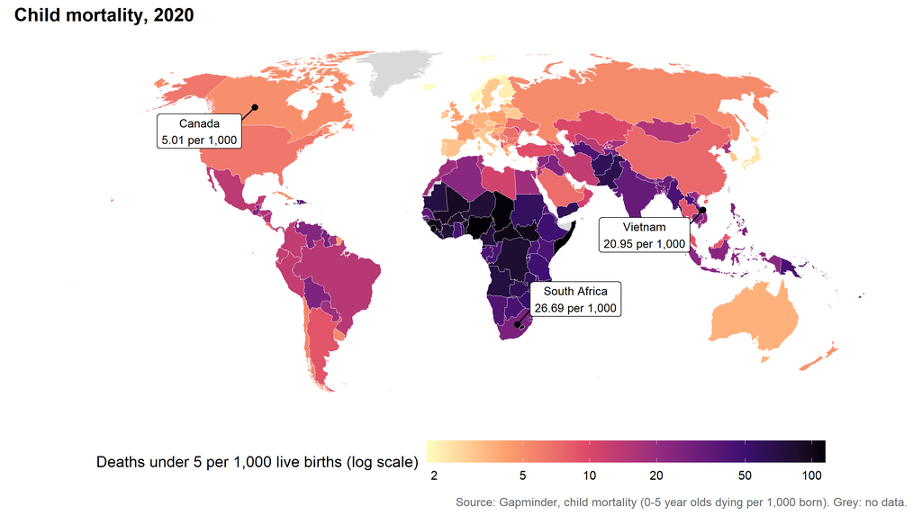

## Map 2: Poverty rate, 2020

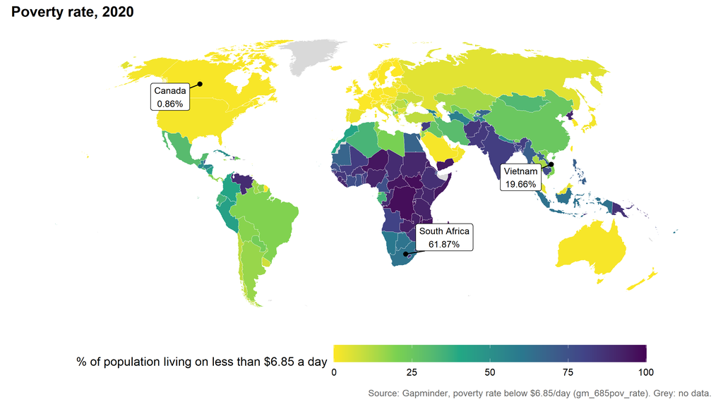

## Relationship between the two indicators

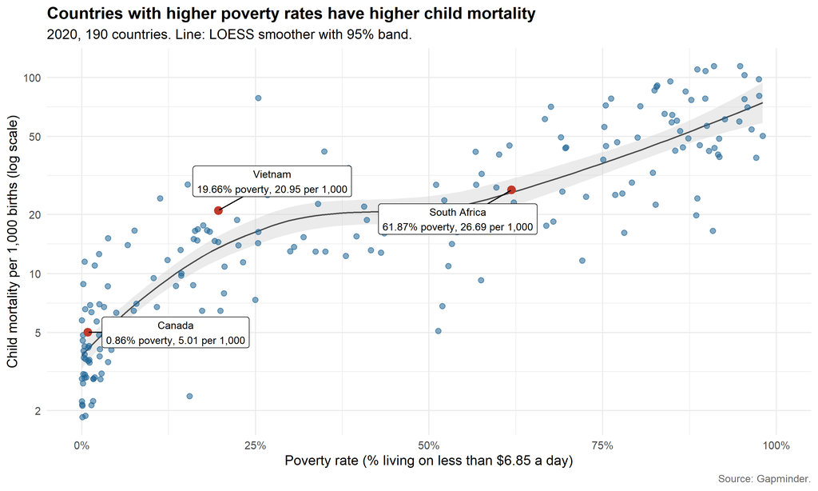

Across the 190 countries, poverty rate and child mortality move together strongly. The rank correlation is Spearman’s ρ = 0.88 and the linear correlation is Pearson’s r = 0.79 (both p < 0.001). Spearman is the better summary here because both indicators are skewed: most countries cluster at low poverty and low mortality, with a long tail of countries that are high on both.

Grouping countries by poverty rate shows the gradient clearly. Median child mortality is 3.6 per 1,000 where 2% or less of people live below $6.85 a day, 13.6 at 10-25% poverty, 26.4 at 50-75%, and 55.9 where more than three quarters of people are poor. The spread within each group is wide, though: among countries with 50-75% poverty, child mortality ranges from 5.1 (Cuba) to 70.8 (Mauritania).

The three highlighted countries follow the overall pattern. Canada sits in the low-poverty, low-mortality corner, Vietnam is in the middle, and South Africa has both the highest poverty rate (61.87%) and the highest child mortality (26.69) of the three. South Africa is close to typical for its poverty level: its child mortality is almost exactly the median of the 50-75% group (26.4). Vietnam’s mortality (20.95) is above the median for its 10-25% poverty group (13.6).

This is a cross-country association for a single year, not evidence that poverty causes child mortality. Both are linked to shared factors such as health system capacity, sanitation, education, and conflict, and country averages hide large differences within countries.

The labelled values on both maps and the scatterplot were checked automatically against the raw 2020 columns of the two CSV files when this report was built. Every country in the data matched a map polygon.

## Beyond poverty: countries off the curve (AI analysis)

To put a number on how much the spread matters, I fitted the same LOESS curve shown in the scatterplot (on the log scale) and compared each country’s actual child mortality with the value “expected” for its poverty rate. Poverty rate accounts for about 79% of the variation in log child mortality across countries, so roughly 21% is left to other factors. The countries furthest from the curve are:

| Direction | Country | Poverty rate, % | Child mortality | Expected from poverty | Actual / expected |
| --- | --- | --- | --- | --- | --- |
| Higher than expected | Equatorial Guinea | 25.4 | 78.6 | 16.5 | 4.76 |
| Higher than expected | Brunei | 0.4 | 11.5 | 4.0 | 2.91 |
| Higher than expected | St. Kitts and Nevis | 3.8 | 15.1 | 5.2 | 2.89 |
| Higher than expected | St. Lucia | 11.3 | 24.2 | 8.8 | 2.75 |
| Higher than expected | Azerbaijan | 2.5 | 12.6 | 4.7 | 2.67 |
| Lower than expected | Montenegro | 15.5 | 2.4 | 11.1 | 0.21 |
| Lower than expected | Cuba | 51.3 | 5.1 | 21.4 | 0.24 |
| Lower than expected | North Korea | 90.8 | 16.5 | 58.7 | 0.28 |
| Lower than expected | Sri Lanka | 51.9 | 6.8 | 21.5 | 0.32 |
| Lower than expected | Belize | 72.0 | 11.7 | 33.7 | 0.35 |

Two patterns stand out. Below the curve are countries such as Cuba and Sri Lanka, which combine high poverty rates at the $6.85 line with child mortality close to that of much richer countries; both are often cited for strong public primary health care. Above the curve are mostly countries with low poverty but higher child mortality than their peers, led by Equatorial Guinea, where oil-driven income has not translated into child survival, and several small or resource-rich states. Some of these comparisons rest on modelled estimates rather than household surveys (North Korea and Cuba in particular), so individual cases should be read with care.

For the highlighted countries, South Africa is almost exactly on the curve (actual / expected = 1.03), Canada is slightly above it (1.22), and Vietnam is noticeably above it (1.55): its child mortality is about 55% higher than the curve predicts for its poverty rate.

## Summary of findings (written by Ryan)

There was a wider spread of child mortality than expected, implying there are other indicators that affect the rate.

## Reflection on working with AI (written by Ryan)

**What was easy**

- What was easy was how good the agent was at installing prerequisites such as R. I also found using Claude Code inside VS Code very easy, even though the assignment requested Cursor or ChatGPT.

**What was difficult**

- The most difficult part was choosing the correct indicators. While an agent could help with this, it highlights the continued need for domain knowledge expertise.
- Maps are inherently difficult because of things like mismatching codes and country names.

**What was surprising**

- For certain countries, such as the occupied Palestinian territories, I expected the maps would not be made well on the first try, and they weren’t: Palestine and South Sudan were left off the first version because of a country code mismatch. What was surprising was that a built-in check caught it, so it could be fixed quickly.
- The agent used pretty standard color wheels for maps.

**What I learned**

- I learned that validating the model, for example by checking that the data was for the year 2020, was very helpful to make sure that the model wasn’t hallucinating.
- This workflow is good for a basic exploratory analysis, but for something more professional or for work, more validation would be required, as well as using things like official admin boundaries.

*Report built in R Markdown with Claude Code (Anthropic) as the AI agent, in place of Cursor. Code is hidden; the source is `week02_report.Rmd` in this folder.*